# Untitled

## Assignment 8: Classification Trees

We’ll be working with the “carseats” dataset from the ISLR package. Run the code below to load the dataset into a dataframe (recall that “tidyverse” dataframes are referred to as tibbles). We’ll then use mutate to create a Yes/No variable to indicate if carseat sales are high or not. We then delete the Sales variable from the dataframe.

```r
carseats = as_tibble(Carseats) %>%
  mutate(High = factor(if_else(Sales <= 8, "No", "Yes"))) %>%
  select(-Sales)
```

The “carseats” dataset is described here: https://rdrr.io/cran/ISLR/man/Carseats.html.

**Q1** The variable types are correct and there is no missingness so we can go ahead and split the dataset. Use a random number seed of 999 and place **80%** of the data into the training set. The response variable is “High”. How many rows are in the training and testing sets?

```r
set.seed(999)
car_split = initial_split(carseats, prop = 0.8, strata = High) #70% in training
train = training(car_split)
test = testing(car_split)
```

- There are 81 obs and 11 variables in the test data set and 319 obs and 11 variables in the train data set.

**Q2** Create appropriate visualizations (using the training set) of each variable versus “High”. To save space you MUST use the grid.arrange function to create grids of charts. You do NOT have to have a single grid of all charts. Consider doing grids of four charts at a time. Your charts should be easily readable/interpretable. Comment on the relationship between each variable and the response variable.

```r
str(carseats)
```

```
tibble [400 × 11] (S3: tbl_df/tbl/data.frame)
 $ CompPrice  : num [1:400] 138 111 113 117 141 124 115 136 132 132 ...
 $ Income     : num [1:400] 73 48 35 100 64 113 105 81 110 113 ...
 $ Advertising: num [1:400] 11 16 10 4 3 13 0 15 0 0 ...
 $ Population : num [1:400] 276 260 269 466 340 501 45 425 108 131 ...
 $ Price      : num [1:400] 120 83 80 97 128 72 108 120 124 124 ...
 $ ShelveLoc  : Factor w/ 3 levels "Bad","Good","Medium": 1 2 3 3 1 1 3 2 3 3 ...
 $ Age        : num [1:400] 42 65 59 55 38 78 71 67 76 76 ...
 $ Education  : num [1:400] 17 10 12 14 13 16 15 10 10 17 ...
 $ Urban      : Factor w/ 2 levels "No","Yes": 2 2 2 2 2 1 2 2 1 1 ...
 $ US         : Factor w/ 2 levels "No","Yes": 2 2 2 2 1 2 1 2 1 2 ...
 $ High       : Factor w/ 2 levels "No","Yes": 2 2 2 1 1 2 1 2 1 1 ...
```

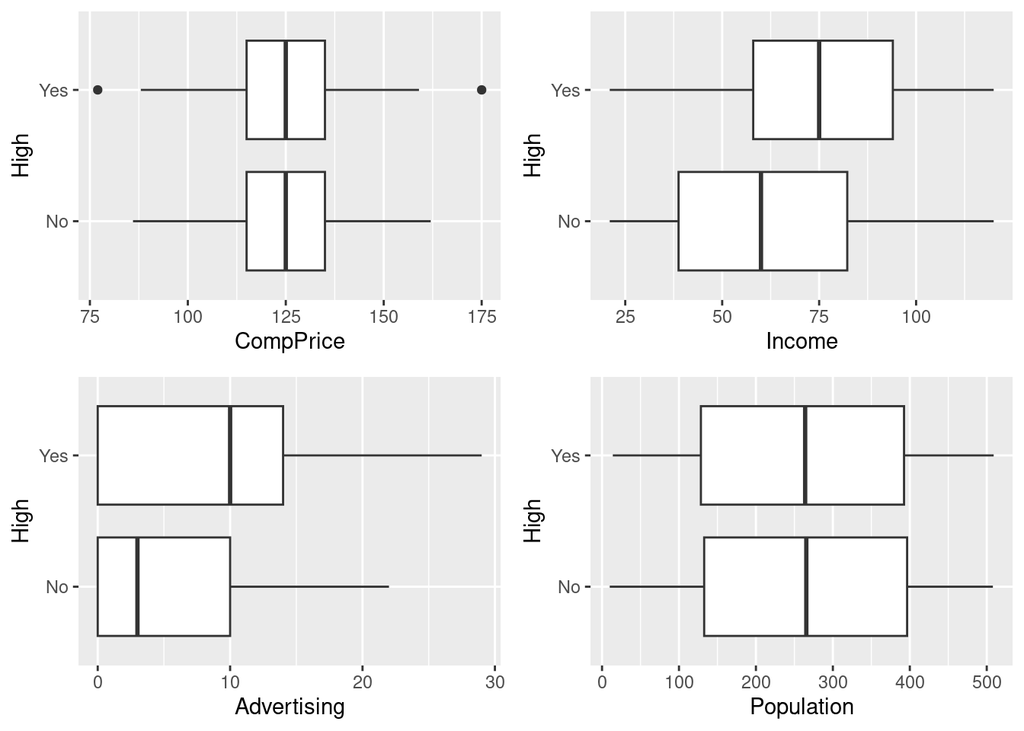

```r
p1 = ggplot(train,aes(y=High,x=CompPrice)) + geom_boxplot()
p2 = ggplot(train,aes(y=High,x=Income)) + geom_boxplot()
p3 = ggplot(train,aes(y=High,x=Advertising)) + geom_boxplot()
p4 = ggplot(train,aes(y=High,x=Population)) + geom_boxplot()

grid.arrange(p1, p2, p3, p4, ncol = 2, nrow = 2)
```

- There does not seem to be a relationship between High and CompPrice
- There does seem to be a significant relationship between High and Income
- There does seem to be a significant relationship between Advertising and High
- There does not seem to be a relationship between Population and High

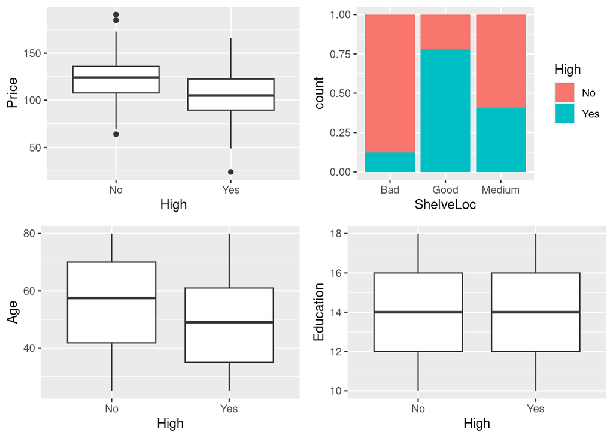

```r
p5 = ggplot(train,aes(High,Price)) + geom_boxplot()
p6 = ggplot(train,aes(x=ShelveLoc,fill=High)) + geom_bar(position = "fill")
p7 = ggplot(train,aes(High,Age)) + geom_boxplot()
p8 = ggplot(train,aes(High,Education)) + geom_boxplot()

grid.arrange(p5, p6, p7, p8, ncol = 2, nrow = 2)
```

- There does seem to be a significant relationship between Price and High
- There does seem to be a significant realtionship between ShelveLoc and High
- There does seem to be a significant relationship between Age and High
- There does not seem to be a relationship between Education and High

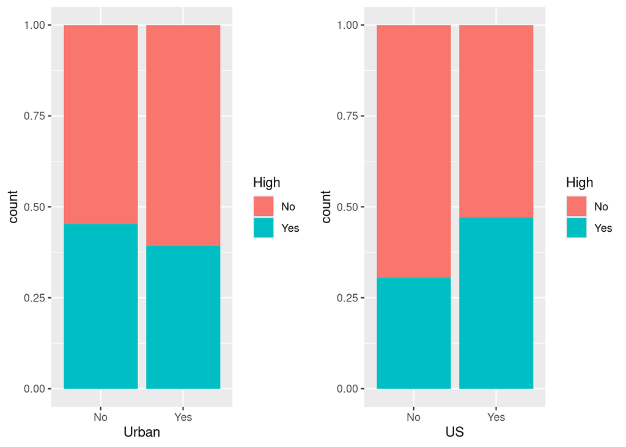

```r
p9 = ggplot(train,aes(x=Urban,fill=High)) + geom_bar(position = "fill")
p10 = ggplot(train,aes(x=US,fill=High)) + geom_bar(position = "fill")

grid.arrange(p9, p10, ncol = 2, nrow = 1)
```

- There seems to be a minor relationship between Urban and High
- There seems to be a significant relationship between US and High

**Q3** Use the Tidymodels framework to build a classification tree on the training set using the “CompPrice” variable to predict “High”. Plot the resulting tree and describe how it would be interpreted.

```r
carseat_recipe = recipe(High ~ CompPrice, train)

tree_model = decision_tree() %>%
  set_engine("rpart", model = TRUE) %>%
  set_mode("classification")

carseat_wflow =
  workflow() %>%
  add_model(tree_model) %>%
  add_recipe(carseat_recipe)

carseat_fit = fit(carseat_wflow, train)
```

```r
tree = carseat_fit %>%
  extract_fit_parsnip() %>%
  pluck("fit")
```

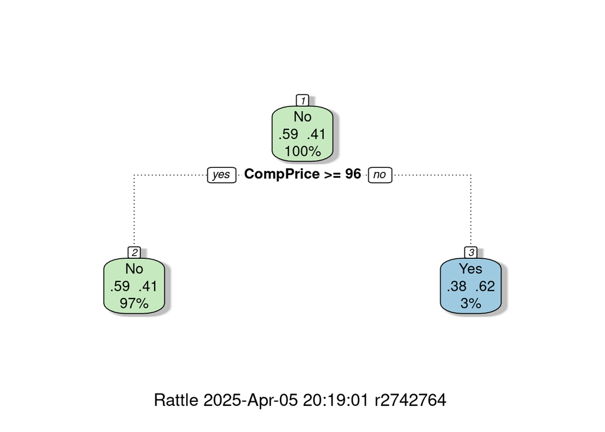

```r
fancyRpartPlot(tree)
```

*Q4* Repeat Q3 but use all variables to predict “High”.

```r
carseat_recipe2 = recipe(High ~ ., train)

tree_model2 = decision_tree() %>%
  set_engine("rpart", model = TRUE) %>%
  set_mode("classification")

carseat_wflow2 =
  workflow() %>%
  add_model(tree_model2) %>%
  add_recipe(carseat_recipe2)

carseat_fit2 = fit(carseat_wflow2, train)
```

```r
tree2 = carseat_fit2 %>%
  extract_fit_parsnip() %>%
  pluck("fit")
```

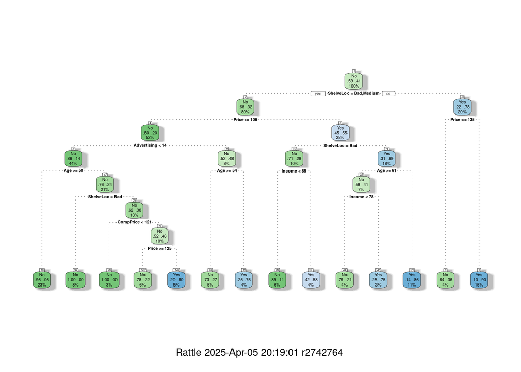

```r
fancyRpartPlot(tree2)
```

- You would use this model the same as the previous one just there are more variable you have to follow but if your example satasifyies the equation go left and if it doesn’t go right. Eventually you will reach the end to get your outcome. Overall while it is possible to use this chart it is tedious and cumbersome. Therefore, a higher chance of operator error can occur which makes this tree not ideal.

*Q5* What is the accuracy of your tree from **Q4** on the training set?

```r
treepred = predict(carseat_fit2, train, type = "class")
```

```r
confusionMatrix(treepred$.pred_class, train$High,positive = "Yes")
```

```
Confusion Matrix and Statistics

          Reference
Prediction  No Yes
       No  165  22
       Yes  23 109

               Accuracy : 0.8589
                 95% CI : (0.8158, 0.8952)
    No Information Rate : 0.5893
    P-Value [Acc > NIR] : <2e-16

                  Kappa : 0.7089

 Mcnemar's Test P-Value : 1

            Sensitivity : 0.8321
            Specificity : 0.8777
         Pos Pred Value : 0.8258
         Neg Pred Value : 0.8824
             Prevalence : 0.4107
         Detection Rate : 0.3417
   Detection Prevalence : 0.4138
      Balanced Accuracy : 0.8549

       'Positive' Class : Yes
```

- There is an accuracy rating of 0.8589 or 85.89%

*Q6* How does your accuracy from **Q5** compare to the naive accuracy?

- The naive accuracy is 0.5893 or 58.93% so our training model is about 27% more accurate.

*Q7* What is the accuracy of your model from **Q5** on the testing set? Does there appear to be evidence of overfitting?

```r
treetest = predict(carseat_fit2, test, type = "class")
```

```r
confusionMatrix(treetest$.pred_class, test$High, positive = "Yes")
```

```
Confusion Matrix and Statistics

          Reference
Prediction No Yes
       No  33   7
       Yes 15  26

               Accuracy : 0.7284
                 95% CI : (0.6181, 0.8213)
    No Information Rate : 0.5926
    P-Value [Acc > NIR] : 0.00773

                  Kappa : 0.458

 Mcnemar's Test P-Value : 0.13559

            Sensitivity : 0.7879
            Specificity : 0.6875
         Pos Pred Value : 0.6341
         Neg Pred Value : 0.8250
             Prevalence : 0.4074
         Detection Rate : 0.3210
   Detection Prevalence : 0.5062
      Balanced Accuracy : 0.7377

       'Positive' Class : Yes
```

- The accuracy of the testing model is 0.7284 or 72.84% so the accuracy did drop about 13% which leads me to believe there is some over fitting.

*Q8* Try tuning the tree you built in **Q4**.This includes both the steps of unguided and guided tuning we discussed in class. Comment on both the steps.

```r
set.seed(234)
folds = vfold_cv(train, v = 5)
```

```r
carseat_recipe3 = recipe(High ~., train) %>%
  step_dummy(all_nominal(),-all_outcomes())

tree_model3 = decision_tree(cost_complexity = tune()) %>%
  set_engine("rpart", model = TRUE) %>% #don't forget the model = TRUE flag
  set_mode("classification")

tree_grid3 = grid_regular(cost_complexity(),
                          levels = 25) #try 25 sensible values for cp

carseat_wflow3 =
  workflow() %>%
  add_model(tree_model) %>%
  add_recipe(carseat_recipe3)

tree_res3 =
  carseat_wflow3 %>%
  tune_grid(
    resamples = folds,
    grid = tree_grid3
    )
tree_res3
```

```
# Tuning results
# 5-fold cross-validation
# A tibble: 5 × 4
  splits           id    .metrics         .notes
  <list>           <chr> <list>           <list>
1 <split [255/64]> Fold1 <tibble [3 × 4]> <tibble [0 × 3]>
2 <split [255/64]> Fold2 <tibble [3 × 4]> <tibble [0 × 3]>
3 <split [255/64]> Fold3 <tibble [3 × 4]> <tibble [0 × 3]>
4 <split [255/64]> Fold4 <tibble [3 × 4]> <tibble [0 × 3]>
5 <split [256/63]> Fold5 <tibble [3 × 4]> <tibble [0 × 3]>
```

```r
best_tree = tree_res3 %>%
  select_best(metric ="accuracy")

best_tree
```

```
# A tibble: 1 × 1
  .config
  <chr>
1 Preprocessor1_Model1
```

```r
final_wf3 =
  carseat_wflow3 %>%
  finalize_workflow(best_tree)
```

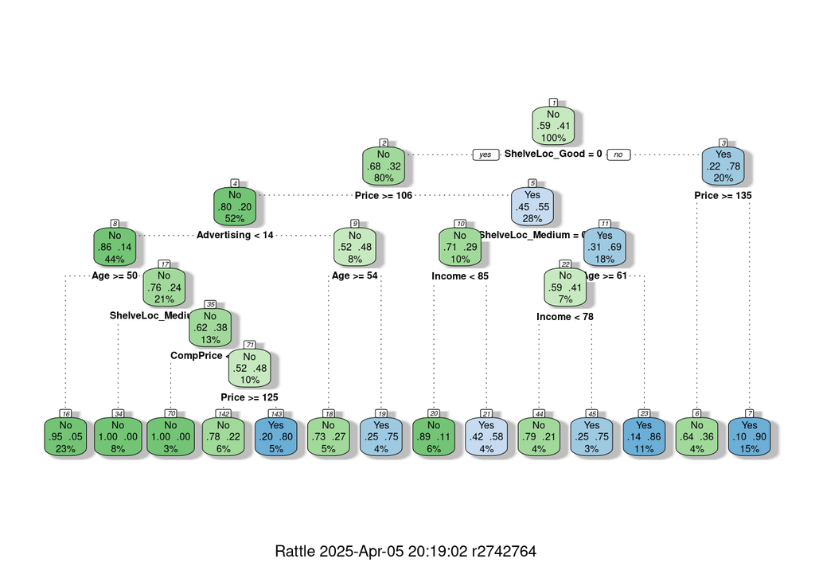

```r
final_fit3 = fit(final_wf3, train)

tree = final_fit3 %>%
  pull_workflow_fit() %>%
  pluck("fit")
fancyRpartPlot(tree, tweak = 1.5)
```

```r
treepred3 = predict(final_fit3, train, type = "class")
head(treepred)
```

```
# A tibble: 6 × 1
  .pred_class
  <fct>
1 No
2 No
3 No
4 No
5 No
6 No
```

```r
confusionMatrix(treepred3$.pred_class, train$High, positive="Yes")
```

```
Confusion Matrix and Statistics

          Reference
Prediction  No Yes
       No  165  22
       Yes  23 109

               Accuracy : 0.8589
                 95% CI : (0.8158, 0.8952)
    No Information Rate : 0.5893
    P-Value [Acc > NIR] : <2e-16

                  Kappa : 0.7089

 Mcnemar's Test P-Value : 1

            Sensitivity : 0.8321
            Specificity : 0.8777
         Pos Pred Value : 0.8258
         Neg Pred Value : 0.8824
             Prevalence : 0.4107
         Detection Rate : 0.3417
   Detection Prevalence : 0.4138
      Balanced Accuracy : 0.8549

       'Positive' Class : Yes
```

```r
treepred_test3 = predict(final_fit3, test, type = "class")
head(treepred_test3)
```

```
# A tibble: 6 × 1
  .pred_class
  <fct>
1 No
2 Yes
3 Yes
4 No
5 Yes
6 Yes
```

```r
confusionMatrix(treepred_test3$.pred_class, test$High, positive="Yes")
```

```
Confusion Matrix and Statistics

          Reference
Prediction No Yes
       No  33   7
       Yes 15  26

               Accuracy : 0.7284
                 95% CI : (0.6181, 0.8213)
    No Information Rate : 0.5926
    P-Value [Acc > NIR] : 0.00773

                  Kappa : 0.458

 Mcnemar's Test P-Value : 0.13559

            Sensitivity : 0.7879
            Specificity : 0.6875
         Pos Pred Value : 0.6341
         Neg Pred Value : 0.8250
             Prevalence : 0.4074
         Detection Rate : 0.3210
   Detection Prevalence : 0.5062
      Balanced Accuracy : 0.7377

       'Positive' Class : Yes
```

- End of unguided tuning

```r
titanic_recipe4 = recipe(High ~., train) %>%
  step_dummy(all_nominal(),-all_outcomes())

tree_model4 = decision_tree(cost_complexity = tune()) %>%
  set_engine("rpart", model = TRUE) %>%
  set_mode("classification")

tree_grid4 = expand.grid(cost_complexity = seq(0.001,0.01,by=0.0001))

titanic_wflow4 =
  workflow() %>%
  add_model(tree_model4) %>%
  add_recipe(titanic_recipe4)

tree_res4 =
  titanic_wflow4 %>%
  tune_grid(
    resamples = folds,
    grid = tree_grid4
    )

tree_res4
```

```
# Tuning results
# 5-fold cross-validation
# A tibble: 5 × 4
  splits           id    .metrics           .notes
  <list>           <chr> <list>             <list>
1 <split [255/64]> Fold1 <tibble [273 × 5]> <tibble [0 × 3]>
2 <split [255/64]> Fold2 <tibble [273 × 5]> <tibble [0 × 3]>
3 <split [255/64]> Fold3 <tibble [273 × 5]> <tibble [0 × 3]>
4 <split [255/64]> Fold4 <tibble [273 × 5]> <tibble [0 × 3]>
5 <split [256/63]> Fold5 <tibble [273 × 5]> <tibble [0 × 3]>
```

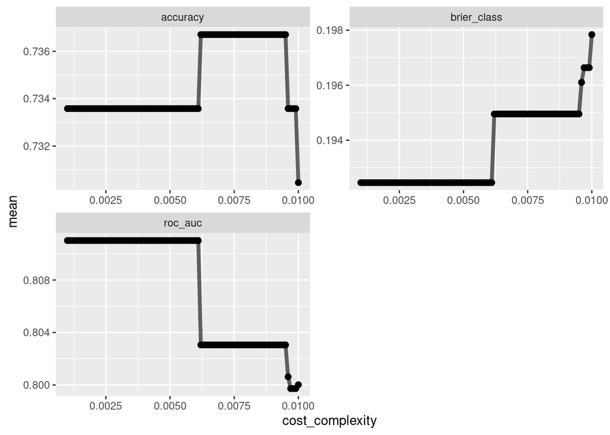

```r
tree_res4 %>%
  collect_metrics() %>%
  ggplot(aes(cost_complexity, mean)) +
  geom_line(size = 1.5, alpha = 0.6) +
  geom_point(size = 2) +
  facet_wrap(~ .metric, scales = "free", nrow = 2)
```

```r
best_tree = tree_res4 %>%
  select_best(metric="accuracy")

best_tree
```

```
# A tibble: 1 × 2
  cost_complexity .config
            <dbl> <chr>
1          0.0062 Preprocessor1_Model53
```

```r
final_wf4 =
  titanic_wflow4 %>%
  finalize_workflow(best_tree)
```

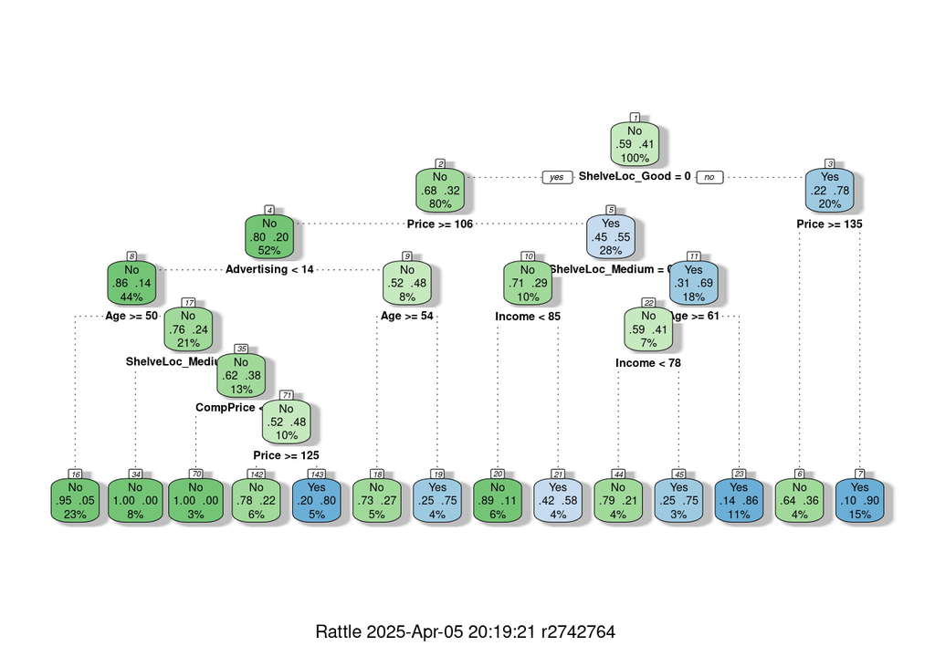

```r
final_fit4 = fit(final_wf4, train)

tree = final_fit4 %>%
  pull_workflow_fit() %>%
  pluck("fit")

fancyRpartPlot(tree, tweak = 1.5)
```

```r
treepred4 = predict(final_fit4, train, type = "class")
head(treepred)
```

```
# A tibble: 6 × 1
  .pred_class
  <fct>
1 No
2 No
3 No
4 No
5 No
6 No
```

```r
confusionMatrix(treepred4$.pred_class, train$High, positive="Yes")
```

```
Confusion Matrix and Statistics

          Reference
Prediction  No Yes
       No  165  22
       Yes  23 109

               Accuracy : 0.8589
                 95% CI : (0.8158, 0.8952)
    No Information Rate : 0.5893
    P-Value [Acc > NIR] : <2e-16

                  Kappa : 0.7089

 Mcnemar's Test P-Value : 1

            Sensitivity : 0.8321
            Specificity : 0.8777
         Pos Pred Value : 0.8258
         Neg Pred Value : 0.8824
             Prevalence : 0.4107
         Detection Rate : 0.3417
   Detection Prevalence : 0.4138
      Balanced Accuracy : 0.8549

       'Positive' Class : Yes
```

```r
treepred_test = predict(final_fit4, test, type = "class")
head(treepred_test)
```

```
# A tibble: 6 × 1
  .pred_class
  <fct>
1 No
2 Yes
3 Yes
4 No
5 Yes
6 Yes
```

```r
confusionMatrix(treepred_test$.pred_class, test$High, positive="Yes")
```

```
Confusion Matrix and Statistics

          Reference
Prediction No Yes
       No  33   7
       Yes 15  26

               Accuracy : 0.7284
                 95% CI : (0.6181, 0.8213)
    No Information Rate : 0.5926
    P-Value [Acc > NIR] : 0.00773

                  Kappa : 0.458

 Mcnemar's Test P-Value : 0.13559

            Sensitivity : 0.7879
            Specificity : 0.6875
         Pos Pred Value : 0.6341
         Neg Pred Value : 0.8250
             Prevalence : 0.4074
         Detection Rate : 0.3210
   Detection Prevalence : 0.5062
      Balanced Accuracy : 0.7377

       'Positive' Class : Yes
```

- End of guided tuning: